# Problem Set 3: IV and LATE

Romu Meango

MT 2025

# Comparing IV, LATE and MTE

This exercise helps you to simulate a Data Generating Process (DGP) satisfying the Roy model, and compare the different estimated effects.

```r
library(dplyr)
library(ggplot2) # For graphics
library(stats)
library(purrr) #for generating random variables

set.seed(180618)



#Generating 5000 observations random sample
N<- 5000
sigma1<- 1.15; sigma0<- 0.5; sigmaV<- 1; sigmaZ <- 3;
alpha0<- 0.02; phi<- 0.2;
gamma0<- 0.2; gamma1<- 0.51; gamma2<- 0.1; gamma3 <- -0.25; rho <- 0.5


set.seed(180618)
eps<- rnorm(N)
Z1<- rnorm(N,-1,sigmaZ)
Z2<- rnorm(N,1,sigmaZ)
Z3<- rbernoulli(N,p=0.3)
U1<- sigma1*eps
U0<- rho*U1 + rnorm(N,0,sigma0)
V<- rnorm(N,0,sigmaV)

# Generate vector of ones (5000x1)
ones<- rep(1,5000)

# Generate Z=(1,Z1,Z2)
Z<- cbind(ones,Z1,Z2,Z3)

# Generate Gamma Vector-> Gamma=(Gamma0,..,Gamma2)
Gamma <- rbind(gamma0,gamma1,gamma2,gamma3)



# Generating Potential Outcomes
Y1<- alpha0 + phi + U1
Y0<- alpha0 + U0

# Get latent Variable I= Z%*%Gamma + V
# Note the selection on gains (Y_1 - Y_0)
I <-  Y1-Y0 + (Z%*%Gamma) + V
U <- -(U1-U0 + V)
F_U <- ecdf(U)

# Get D= Indicator[I>=0]
D<- ifelse(I>=0, 1, 0)

# Generate Y= DY1 + (1-D)Y0
Y<- D*Y1 + (1-D)*Y0

# Save in a data frame
Df<- data.frame('Delta' = Y1 - Y0, 'Y' = Y,
                'Y1' = Y1, 'Y0' = Y0,
                'DecVar' = D, 'Latent' = I, 'UnObs' = V,
                'Z1' = Z1, 'Z2' = Z2, 'Z3' = Z3)
```

2. Compute the ATE, ATT, and ATNT on your sample. Compare to the distribution of $Y_1 - Y_0$.

```r
(ATE<- Df %>% pull(Delta) %>% mean())
```

```
## [1] 0.2064249
```

```r
(ATT<- Df %>% filter(DecVar == 1) %>% pull(Delta) %>% mean())
```

```
## [1] 0.4453636
```

```r
(ATNT<- Df %>% filter(DecVar == 0) %>% pull(Delta) %>% mean())
```

```
## [1] -0.01805507
```

```r
(MTE <- Df %>% filter(abs(phi+(Z%*%Gamma)+U) <= 0.005) %>% pull(Delta) %>%
    mean())
```

```
## [1] -0.03537088
```

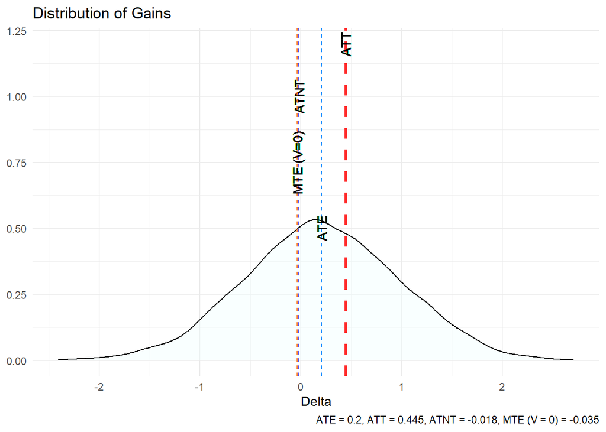

```r
ggplot(Df, aes(x = Delta, y = after_stat(density))) +
  geom_density(alpha = 0.4, fill = 'azure') +
  geom_vline(xintercept = ATE, linetype = 'dashed', colour = 'dodgerblue') +
  geom_text(aes(x = ATE - 0.0003, y = 0.5, label = 'ATE'), angle = 90) +
  geom_vline(xintercept = ATT,
             linetype = 'dashed',
             colour = 'firebrick1', size= 1.2) +
  geom_text(aes(x = ATT - 0.0003, y =1.2 , label = 'ATT'), angle = 90) +
  geom_vline(xintercept = ATNT,
             linetype = 'dashed',
             colour = 'blue1') +
  geom_text(aes(x = ATNT - 0.0003, y = 1, label = 'ATNT'), angle = 90) +
  geom_vline(xintercept = MTE,
             linetype = 'dashed',
             colour = 'chocolate1') +
  geom_text(aes(x = MTE + 0.001, y = 0.75, label = 'MTE (V=0)'), angle = 90) +
  labs(
    title = 'Distribution of Gains',
    x = 'Delta',
    y = NULL,
    caption = paste0(
      'ATE = ' ,round(ATE,1),

      ', ATT = ' , round(ATT,3),

      ', ATNT = ', round(ATNT,3),

      ', MTE (V = 0) = ', round(MTE,3)
    )
  )+theme_minimal()
```

3. Estimate the OLS, and IV using $Z_1$ only, $Z_2$ only, then $Z_3$ only. Compare to the density distribution of $Y_1 - Y_0$.

```r
library(AER)

## ---- OLS
(OLS<- cov(Y,D) / var(D))
```

```
##           [,1]
## [1,] 0.5253058
```

```r
ols_Estimate <- lm(data = Df, Y ~ DecVar)
confint(ols_Estimate, 'DecVar', level=0.95)
```

```
##           2.5 %    97.5 %
## DecVar 0.471941 0.5786707
```

```r
## ---- IV - 2SLS (z1)
(LATE.Z1.IV<- cov(Z[,2], Y) / cov(Z[,2], D))
```

```
##           [,1]
## [1,] 0.2575456
```

```r
iv_Estimate <- ivreg(data = Df, Y ~ DecVar | Z1)
confint(iv_Estimate, 'DecVar', level=0.95)
```

```
##            2.5 %    97.5 %
## DecVar 0.1692213 0.3458699
```

This is fortuitously close from the ATE.

```r
## ---- IV - 2SLS (z2)
(LATE.Z2.IV<- cov(Z[,3], Y) / cov(Z[,3], D))
```

```
##           [,1]
## [1,] 0.6143706
```

```r
iv_Estimate <- ivreg(data = Df, Y ~ DecVar | Z2)
confint(iv_Estimate, 'DecVar', level=0.95)
```

```
##            2.5 %    97.5 %
## DecVar 0.2423793 0.9863618
```

This is far from the ATE - but represents a Local ATE.

```r
## ---- LATE - (z3=0 to z3 =1)
(LATE.Z3.IV<- cov(Z[,4], Y) / cov(Z[,4], D))
```

```
##           [,1]
## [1,] 0.2761119
```

```r
iv_Estimate <- ivreg(data = Df, Y ~ DecVar | Z3)
confint(iv_Estimate, 'DecVar', level=0.95)
```

```
##             2.5 %   97.5 %
## DecVar -0.9632569 1.515481
```

This is not too far from the ATE, but noisy (would not reject 0)

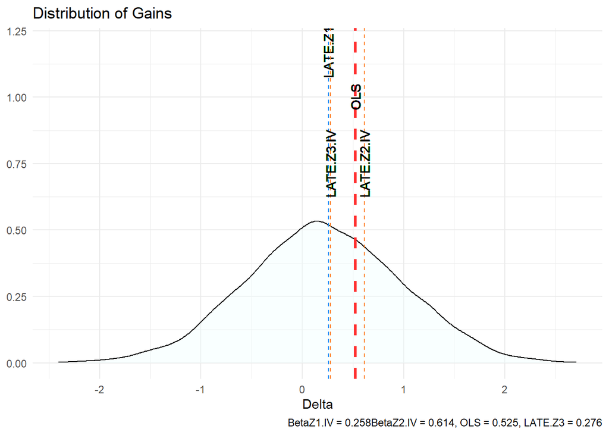

```r
#---- Plot againt Y_1 - Y_0

ggplot(Df, aes(x = Delta, y = after_stat(density))) +
  geom_density(alpha = 0.4, fill = 'azure') +
  geom_vline(xintercept = LATE.Z1.IV,
             linetype = 'dashed',
             colour = 'dodgerblue') +
  geom_text(aes(x = LATE.Z1.IV - 0.0003, y = 1.2, label = 'LATE.Z1.IV'), angle = 90) +
  geom_vline(xintercept = OLS,
             linetype = 'dashed',
             colour = 'firebrick1', size= 1.2) +
  geom_text(aes(x = OLS - 0.0005, y =1 , label = 'OLS'), angle = 90) +
  geom_vline(xintercept = LATE.Z2.IV,
             linetype = 'dashed',
             colour = 'chocolate1') +
  geom_text(aes(x = LATE.Z2.IV - 0.0003, y = 0.75, label = 'LATE.Z2.IV'), angle = 90) +
  geom_vline(xintercept = LATE.Z3.IV,
             linetype = 'dashed',
             colour = 'chocolate1') +
  geom_text(aes(x = LATE.Z3.IV - 0.0003, y = 0.75, label = 'LATE.Z3.IV'), angle = 90) +
  labs(
    title = 'Distribution of Gains',
    x = 'Delta',
    y = NULL,
    caption = paste0(
      'BetaZ1.IV = ' ,round(LATE.Z1.IV,3),
      'BetaZ2.IV = ' ,round(LATE.Z2.IV,3),
      ', OLS = ' ,round(OLS,3),
      ', LATE.Z3 = ' ,round(LATE.Z3.IV,3)
      )
  )+theme_minimal()
```

## Angrist and Evans (1998)

This question uses the setup of Angrist and Evans (AER, 1998, AE henceforth). You can find the paper here: https://www.jstor.org/stable/116844. The study uses parental preferences for a mixed sibling-sex composition to construct instrumental variables (IV) estimates of the effect of childbearing on labor supply.

1. The dataset is available from the library `ivmte`,under the name `AE`. Upload the data and create a summary table of the variables in your dataset. Most variables are self-explanatory:
- `morekids` is a dummy that records whether the woman has had three or more children,
- `samesex` records whether the two first children have the same gender,
- `yob` stands for year of birth,
- `worked` is dummy recording labour force participation (worked for pay) in the year prior to census.

```r
# For Angrist and Evans (1998) data
library(ivmte)
library(dplyr)
library(modelsummary)
# Upload Data
my_AE <- AE

# Create a Summary table of the variables in your dataset.
datasummary_skim(my_AE)
```

Unique (#)

Missing (%)

Mean

SD

Min

Median

Max

worked

2

0

0.5

0.5

0.0

1.0

1.0

[figure not shown]

hours

96

0

16.9

18.4

0.0

9.0

99.0

[figure not shown]

morekids

2

0

0.3

0.5

0.0

0.0

1.0

[figure not shown]

samesex

2

0

0.5

0.5

0.0

1.0

1.0

[figure not shown]

yob

15

0

48.0

2.8

44.0

48.0

58.0

[figure not shown]

black

2

0

0.1

0.3

0.0

0.0

1.0

[figure not shown]

hisp

2

0

0.0

0.2

0.0

0.0

1.0

[figure not shown]

other

2

0

0.0

0.2

0.0

0.0

1.0

[figure not shown]

```r
datasummary_balance(~samesex,data = my_AE)
```

|  | 0 Mean | 0 Std. Dev. | 1 Mean | 1 Std. Dev. | Diff. in Means | Std. Error |
| --- | --- | --- | --- | --- | --- | --- |
| worked | 0.5 | 0.5 | 0.5 | 0.5 | 0.0 | 0.0 |
| hours | 17.0 | 18.4 | 16.8 | 18.3 | -0.2 | 0.1 |
| morekids | 0.3 | 0.5 | 0.4 | 0.5 | 0.1 | 0.0 |
| yob | 48.0 | 2.8 | 48.0 | 2.8 | 0.0 | 0.0 |
| black | 0.1 | 0.3 | 0.1 | 0.3 | 0.0 | 0.0 |
| hisp | 0.0 | 0.2 | 0.0 | 0.2 | 0.0 | 0.0 |
| other | 0.0 | 0.2 | 0.0 | 0.2 | 0.0 | 0.0 |

2. AE use the fact that the two first children are of the same sex as an exogenous variation for the decision to have three children or more. What are the identifying assumptions? Are the covariates balanced across the instruments `samesex`?

Identifying assumptions in more general case of an heterogeneous treatment effect:

- Exclusion: the gender of the two first children does not affect directly the decision to work, apart from the decision to have more than three children.
- Relevance: Parents with children of the same sex will have, on average, an additional incentive to have a third child.
- Monotonicity: Having two children of the same sex does not discourage from having a third child.
- Exogeneity: The gender of the first two children is independent of the mother potential outcomes.

```r
library(RCT) # for balance_table
library(stargazer)

my_AE_cov <- my_AE %>%
  dplyr::select(samesex, yob, black, hisp, other)

bal_tab <- as.data.frame(balance_table(my_AE_cov, "samesex"))

names(bal_tab) <- c("Variable", "Mean (samesex=0)", "Mean (samesex=1)", "P-value for difference in means")

stargazer(bal_tab,
type = "text",
summary = FALSE,
rownames = FALSE)
```

```
##
## ==========================================================================
## Variable Mean (samesex=0) Mean (samesex=1) P-value for difference in means
## --------------------------------------------------------------------------
## black         0.068            0.067                    0.552
## hisp          0.024            0.024                    0.778
## other         0.034            0.033                    0.145
## yob           48.017           48.027                   0.406
## --------------------------------------------------------------------------
```

3. Estimate the OLS and IV estimator of the effect of more kids on the decision to work, using the command `lm` and `ivreg`. Interpret their value, and the discrepancy between the two.

```r
library(estimatr)

# OLS Regression
lm(data = my_AE, worked ~ morekids)
```

```
##
## Call:
## lm(formula = worked ~ morekids, data = my_AE)
##
## Coefficients:
## (Intercept)     morekids
##      0.5822      -0.1423
```

```r
library(AER)
# IV regression
ivreg(data = my_AE, worked ~ morekids | samesex )
```

```
##
## Call:
## ivreg(formula = worked ~ morekids | samesex, data = my_AE)
##
## Coefficients:
## (Intercept)     morekids
##     0.56315     -0.08484
```

Both estimators suggest a negative effect of children on the probability to work. The OLS is more negative, suggesting that Mothers with more children, are also those with the lowest wish to enter the labour market.

4. Describe in words what the IV estimates. Provide a description of the characteristics of the compliers using the statistics $P(D_1>D_0)$, $P(D_1>D_0 \vert D=1)$, $P(D_1>D_0 \vert D=0)$, $P(x \vert D_1 > D_0) / P(x)$ with usual notations, and $x$ being, respectively, an indicator for the age being lower than the median, and a dummy for being non-white. Note that:
   $$\frac{P(X = 1|D(1) > D(0)) }{P(X = 1)} = \frac{\mathbb{E}(D|Z=1, X =1) - \mathbb{E}(D|Z=0,X =1)}{\mathbb{E}(D|Z=1) - \mathbb{E}(D|Z=0)}$$

```r
 # Create variables needed below
my_AE <- my_AE %>%
  mutate(log_hours = log(1+hours)) %>%
  mutate(race_dummy = black + hisp + other) %>%
  mutate(yob_dummy = yob > median(yob))

# Provide a description of the characteristics of the compliers:
# $P(D_1>D_0)$, $P(D_1>D_0 \vert D=0)$, $P(D_1>D_0 \vert D=0)$
# $P(x \vert D_1 > D_0) , P(x \vert D_1 > D_0) / P(X)$ with $x$ being the $yob>median(yob)$, a dummy for being non-white.

# $P(D_1>D_0)$
first_stage <- mean(my_AE[my_AE$samesex==1,]$morekids) - mean(my_AE[my_AE$samesex==0,]$morekids)
first_stage
```

```
## [1] 0.05886826
```

```r
#or
first_stage <- my_AE %>%
  group_by(samesex)%>%
  summarize(EDz = mean(morekids))%>%
  pull(EDz)%>%
  diff()



#$P(D_1>D_0 \vert D=1)$
mean(my_AE$samesex)/mean(my_AE$morekids)*first_stage
```

```
## [1] 0.08979314
```

```r
#$P(D_1>D_0 \vert D=0)$
(1-mean(my_AE$samesex))/(1-mean(my_AE$morekids))*first_stage
```

```
## [1] 0.04350178
```

```r
#$P(x \vert D_1 > D_0) / P(x)$
# race dummy
my_AE%>%
  filter(race_dummy==1) %>%
  group_by(samesex) %>%
  summarise(meanD=mean(morekids))%>%
  pull(meanD)%>%
  diff() %>%
  magrittr::divide_by(first_stage)
```

```
## [1] 0.8344731
```

```r
# yob dummy
my_AE%>%
  filter(yob_dummy==1) %>%
  group_by(samesex) %>%
  summarise(meanD=mean(morekids))%>%
  pull(meanD)%>%
  diff() %>%
  magrittr::divide_by(first_stage)
```

```
## [1] 0.8787303
```

5. A researcher would like to estimate the LATE for white women, while introducing controls for the year of birth. Under which conditions would the 2SLS estimator identify the LATE. Write down a proper 2SLS equation in this case, that would avoid negative weights.

The two-SLS needs to be saturated, that is the researcher needs to define a set of dummy variables, one for each year of birth, then fully interact them with treatment variables. For $t=0$ the excluded category:

$$\begin{eqnarray}
morekids &=& b_0 + \alpha_0 samesex + \sum_{t=1}^t \alpha_{1t} I\{yob = t\} + \sum_{t=1}^t \alpha_{2t} samesex \cdot I\{yob = t\} + u_d\\
Y &=& c_0 + \beta_0 morekids + \sum_{t=1}^T \beta_{1t} I\{yob = t\} + \sum_{t=1}^T \beta_{2t} morekids \cdot I\{yob = t\} + u_y
\end{eqnarray}$$

6. One alternative from Frölich (2007) consists in estimating the ratio between two matching estimators. In which sense are these matching estimators? What is the ‘treatment’, what do we match upon?

The treatment here is having the instrument “switched on”. The estimator matches on the observable covariates. This approach is valid because the instrument $Z$ satisfies the conditions for unconfoundedness.

7. We wish to estimate the equation below using local polynomial regression.
   $$\widehat{E}(Y_1 - Y_0 \vert T=c)= \dfrac{\sum_{i:Z_i=1} \bigl({Y_i - \widehat{m}_0(X_i) }\bigr) - \sum_{i:Z_i=0} \bigl({Y_i - \widehat{m}_1(X_i) }\bigr) }{\sum_{i:Z_i=1} \bigl({D_i - \widehat{\mu}_0(X_i) }\bigr) -\sum_{i:Z_i=0} \bigl({D_i - \widehat{\mu}_1(X_i) }\bigr) } \;\;\;\;\;\;\;\;\text{(ME)}$$
   where:
   $$\begin{array}{l}
   \widehat{m}_z(x) = \widehat{E}(Y \vert X=x, Z=z) \text{: a nonparametric estimator of the conditional moment, } \\
   \widehat{\mu}_z(x) = \widehat{E}(D \vert X=x, Z=z) \text{: a nonparametric estimator of the propensity score. }
   \end{array}$$
   We will use the function `loess` from the package `stats`. Write a function that takes `y`,`x`,`z`,`span`,`deg` as arguments, estimates $\hat{E}(y \vert X=x, Z=z)$, and compute the difference in averages. You may want to use the following steps:
- `loess` is computationally demanding, and our dataset is large. Draw a subsample $N=10,000$, after setting the seed to 8.
- Initiate the function.
- using the function `loess`, estimate by local linear regression the function $m_1(x)$, with bandwidth (span) equals 1 on the subset of the population such that $Z_i=1$.
- Repeat the previous step to estimate $m_0(x)$ on the subset of the population such that $Z_i=0$
- predict $m_1(X_i)$ for individuals with $Z_i =0$, and $m_0(X_i)$ for individuals with $Z_i =1$
- Compute the difference $Y_i - m_z(X_i)$,
- The output of the function is the sum of the above differences over the relevant sub-samples.

Finally, use your newly written function to estimate the numerator and denominator of Equation (ME). Compute the LATE. Assess the sensitivity to your choice of `deg` and `span`. Compare the estimate to the OLS and IV estimates. Note: you will need to re-compute the OLS and IV on the random sub-sample of size $N$.

```r
set.seed(8)
my_AE <- my_AE %>%
  filter(race_dummy==0)

df <-  my_AE[sample(nrow(my_AE), 10000), ]

# As before
# OLS Regression
lm(data = df, worked ~ morekids )
```

```
##
## Call:
## lm(formula = worked ~ morekids, data = df)
##
## Coefficients:
## (Intercept)     morekids
##      0.5717      -0.1592
```

```r
# IV regression
ivreg(data = df, worked ~ morekids | samesex )
```

```
##
## Call:
## ivreg(formula = worked ~ morekids | samesex, data = df)
##
## Coefficients:
## (Intercept)     morekids
##     0.52523     -0.01583
```

```r
# Including yob as a control variable
# OLS Regression
lm(data = df, worked ~ morekids + yob)
```

```
##
## Call:
## lm(formula = worked ~ morekids + yob, data = df)
##
## Coefficients:
## (Intercept)     morekids          yob
##     1.30289     -0.16936     -0.01516
```

```r
# IV regression
ivreg(data = df, worked ~ morekids +yob | samesex + yob )
```

```
##
## Call:
## ivreg(formula = worked ~ morekids + yob | samesex + yob, data = df)
##
## Coefficients:
## (Intercept)     morekids          yob
##     1.10994     -0.01176     -0.01221
```

```r
matching_estimator <- function(df,
                     y,
                     x,
                     z,
                     span,
                     deg) {

  # Renaming the columns for convenience
  # (i.e. not using {{ }} afterwards)
  df <- df %>%
    rename(y := {{y}},
           x := {{x}},
           z := {{z}})

r1 <- loess(y~x,df[df$z==1,],span = span, deg = deg)
m1 <- predict(r1, df$x, se = TRUE,na.omit)
#plot(df$x,m1$fit)

r0 <- loess(y~x,df[df$z==0,],span = 1,deg = 1)
m0 <- predict(r0, df$x, se = TRUE,na.omit)
#plot(df$x,m0$fit)

sum(is.na(m1$fit))

df %>%
  mutate(ind_diff = ifelse(z==1, y - m0$fit, y - m1$fit)) %>%
  group_by(z) %>%
  filter(is.na(ind_diff)==0)%>%
  summarize(sum_diff = sum(ind_diff))%>%
  pull(sum_diff)%>%
  diff()
}

# Use this function to estimate the numerator and the denominator of Equation (). Compute the LATE and compare it to the previous estimates of the LATE.

numerator <- matching_estimator(df = df, y = worked, x = yob, z = samesex, deg = 1, span = 0.5)
denominator <- matching_estimator(df = df, y = morekids, x = yob, z = samesex, deg = 1, span = 0.5)

numerator/denominator
```

```
## [1] -0.01729273
```

The point estimate of the IV-2SLS is very close to the Frölich (2007) estimator, and far from the OLS. It is hard to draw any conclusion here because we need to test properly whether the two coefficients are different. Ideally, we would want to bootstrap the standard errors and use the whole sample.

8. A second alternative is to use the ratio of two weighted regressions. Using the function `lateweight` within the package `causalweight`, estimate the LATE. The documentation is available here: https://core.ac.uk/download/pdf/154769223.pdf. Compare it with the previous estimates. Does the result change with trimming on the propensity score? Why?

```r
library(causalweight)
est0<- lateweight(y=df$worked,d=df$morekids,z=df$samesex,x=df$yob,trim=0.1,LATT=FALSE,logit=TRUE,boot=19)
cat("LATE: ",round(c(est0$effect),7),", standard error: ",
             round(c(est0$se.effect),7), ", p-value: ",
             round(c(est0$pval.effect),7))
```

```
## LATE:  -0.0117704 , standard error:  0.1157074 , p-value:  0.9189742
```

```r
est1<- lateweight(y=df$worked,d=df$morekids,z=df$samesex,x=df$yob,trim=0.05,LATT=FALSE,logit=TRUE,boot=19)
cat("LATE: ",round(c(est1$effect),7),", standard error: ",
             round(c(est1$se.effect),7), ", p-value: ",
             round(c(est1$pval.effect),7))
```

```
## LATE:  -0.0117704 , standard error:  0.1177308 , p-value:  0.9203621
```

```r
est2<- lateweight(y=df$worked,d=df$morekids,z=df$samesex,x=df$yob,trim=0.01,LATT=FALSE,logit=TRUE,boot=19)
cat("LATE: ",round(c(est2$effect),7),", standard error: ",
             round(c(est2$se.effect),7), ", p-value: ",
             round(c(est2$pval.effect),7))
```

```
## LATE:  -0.0117704 , standard error:  0.1339569 , p-value:  0.9299821
```

The estimator is insensitive to the trimming. This is because the propensity score is close to 0.5. The point estimate is very close to the previous procedures, which is reassuring.

# Returns to a STEM degree

Examining the returns to education (how much one more year of education increases your lifetime income) is a well-studied problem in applied econometrics. Returns to different degrees is less studied but seems quantitatively just as important. One usual distinction is between STEM (Science, Technology, Engineering and Mathematics) and other degrees.

The data we will use is from a graduate survey. The population pools several cohorts of graduates in Germany who have completed tertiary education. They are observed five years after graduation.

The data contains the following variables:

- `age`: age at the time of the survey.
- `fem`: equals 1 if the respondent is a woman.
- `stemdeg`: equals 1 if the respondent has a STEM degree.
- `grade_abitur`: the grade at the secondary school exam (Abitur). It has been normalised to be between 0 and 100 percent.
- `binfathered` (resp. `binmothered`): equals 1 if the father (resp. the mother) has tertiary education.
- `income_5yrs`: the hourly wage after five years of graduation.
- `no_regret`: the respondent’s answer to the question: ‘if you could choose again, would you do the same degree?’ It equals 1 when the answer is ‘yes’.
- `related_job`: equals 1 if the respondent holds a job related to his/her degree.
- `bin_prop_faculty_stem`: equals 1 if proportion of female faculty in the year and region of Abitur is above the national average.

A researcher is interested in the distribution of graduates outcomes after graduation in a STEM degree.

1. Present a data summary of pertinent variables and compare the STEM degree holders to the non-degree holders. Tipp: Some data cleaning: Drop the extreme values of wages (below 5% and above 95% quantile). It is standard to use log-income rather than income level.
2. The researcher assumes first that all selection into STEM degree is based on observable characteristics. Denote $(Y_0,Y_1)$ the potential outcomes, where the subscript 1 refers to STEM degrees. How would you estimate the marginal distributions $F_{Y_0}(y)$ and $F_{Y_1}(y)$?
3. Implement your choice for $Y$ being successively the variables `income_5yrs`, `no_regret`, and `related_job`. If necessary, show the results on a graph. Explain your choice of control variables. Finally comment on the difference between both distributions.
4. The researcher focuses on the returns to STEM education for women and would like to use a binary instrumental variable $Z$. What are the conditions to estimate the marginal distributions of the potential outcomes $F_{Y_0}(y)$ and $F_{Y_1}(y)$ in the LATE model? How would you estimate them?
5. The researcher argues that one can use either of the following variables as an excluded variable:
- the mother’s education `binmothered`, which equals 1 when the mother has obtained tertiary education.
- the proportion of female STEM faculty `bin_prop_female_faculty_stem`, which equals one, if in the year and in the province where one has completed secondary school, the proportion of faculty teaching STEM subjects is above the average proportion in the country. Could you argue in favour or against each instrument? Which one would you prefer? Please explain.
6. Compare the population of compliers (among women) between each of the two instruments. Please summarise your statistics in a table.
7. Estimate the marginal distributions for the compliers (among women) by adapting estimator (2) of Frohlich (2007). The formula in the lecture notes was:

   $$\widehat{E}(Y_1 - Y_0 \vert T=c)= \dfrac{\sum_{i} \bigl({Y_i Z_i / \widehat{\pi}(X_i) - Y_i (1-Z_i) / (1-\widehat{\pi}(X_i)) }\bigr)}{\sum_{i} \bigl({D_i Z_i / \widehat{\pi}(X_i) - D_i (1-Z_i) / (1-\widehat{\pi}(X_i)) }\bigr)}$$
   where
   $$\widehat{\pi}(x) = \hat{E}(D \vert X=x), \text{ a nonparametric estimator of the propensity score}.$$
   Comment on the difference of distributions for $Y$ being successively the variables `income_5yrs`, `no_regret`, and `related_job`. Please, assume that `grade_abitur` is the only regressor that you need to include.
8. Test for the hypothesis $H_0: F_{Y_0}=F_{Y_1}$ among the compliers. Explain carefully your testing procedure. Please, ignore any regressor.
9. Given all your findings above, write a short abstract (max. 150 words) of a paper that would present your research about the returns to STEM degrees in Germany.